# HW4 Peer Assessment

Fri Mar 24 21:02:39 2023 -05

# Background

The owner of a company would like to be able to predict whether employees will stay with the company or leave.

## Data Description

The data contains information about various characteristics of employees. Please note that the dataset has been updated to account for repetitions, which is needed for Goodness of Fit Assessment. See below for the description of these characteristics.

1. **Age.Group**: 1-9 (1 corresponds to teen, 2 corresponds to twenties, etc.)
2. **Gender**: 1 if male, 0 if female
3. **Tenure**: Number of years with the company
4. **Num.Of.Products**: Number of products owned
5. **Is.Active.Member**: 1 if active member, 0 if inactive member
6. **Staying**: Fraction of employees that stayed with the company for a given set of predicting variables.

## Setup

You can import the data and set up the problem with the following R code:

```r
# Import the data
rawdata = read.csv("hw4_data.csv", header=TRUE, fileEncoding="UTF-8-BOM")

# Create variable Staying
rawdata$Staying = rawdata$Stay/rawdata$Employees

# Set variables as categoricals
rawdata$Num.Of.Products<-as.factor(rawdata$Num.Of.Products)
rawdata$Age.Group<-as.factor(rawdata$Age.Group)
rawdata$Gender<-as.factor(rawdata$Gender)
rawdata$Is.Active.Member<-as.factor(rawdata$Is.Active.Member)


# Print head of rawdata
head(rawdata)
```

|  | Age.Group | Gender | Tenure | Num.Of.Products | Is.Active.Member | Stay | Employees | Staying |
| --- | --- | --- | --- | --- | --- | --- | --- | --- |
| 1 | 2 | 1 | 3 | 1 | 0 | 5 | 11 | 0.4545455 |
| 2 | 2 | 1 | 4 | 1 | 0 | 5 | 10 | 0.5000000 |
| 3 | 2 | 1 | 4 | 1 | 1 | 2 | 13 | 0.1538462 |
| 4 | 2 | 0 | 7 | 1 | 0 | 3 | 10 | 0.3000000 |
| 5 | 2 | 1 | 7 | 1 | 0 | 2 | 14 | 0.1428571 |
| 6 | 2 | 0 | 4 | 2 | 0 | 4 | 12 | 0.3333333 |

```r
unique(rawdata$Num.Of.Products)
```

```
## [1] 1 2
## Levels: 1 2
```

**Note:** For all of the following questions, treat variables **Tenure** and **Staying** as quantitative variables and **Age.Group**, **Gender**, **Num.Of.Products**, and **Is.Active.Member** as categorical variables. Categorical variables have already been converted to factors in the starter code.

# Question 1: Fitting a Model - 9 pts

Fit a logistic regression model using *Staying* as the response variable with *Num.Of.Products* as the predictor and logit as the link function. Ensure to include the weights parameter for specifying the number of trials. Call it **model1**. Note that *Num.Of.Products* should be treated as a categorical variable.

1. 3 pts - Display the summary of model1. What are the model parameters and estimates?

```r
model1 = glm( Staying ~ Num.Of.Products,weight = Employees,  data = rawdata, family=binomial)
summary(model1)
```

```
##
## Call:
## glm(formula = Staying ~ Num.Of.Products, family = binomial, data = rawdata,
##     weights = Employees)
##
## Deviance Residuals:
##     Min       1Q   Median       3Q      Max
## -4.2827  -1.4676  -0.1022   1.4490   4.7231
##
## Coefficients:
##                  Estimate Std. Error z value Pr(>|z|)
## (Intercept)       0.37886    0.04743   7.988 1.37e-15 ***
## Num.Of.Products2 -1.76683    0.10313 -17.132  < 2e-16 ***
## ---
## Signif. codes:  0 '***' 0.001 '**' 0.01 '*' 0.05 '.' 0.1 ' ' 1
##
## (Dispersion parameter for binomial family taken to be 1)
##
##     Null deviance: 981.04  on 157  degrees of freedom
## Residual deviance: 632.04  on 156  degrees of freedom
## AIC: 1056.8
##
## Number of Fisher Scoring iterations: 4
```

**ANSWER:** The model parameters here for model1 are the intercept B0 and B1.

2. 3 pts - Write down the equation for the **Odds** of Staying.

3. 3 pts - Provide a meaningful interpretation for the estimated coefficient for *Num.Of.Products2* with respect to the log-odds of staying and the odds of staying.

**ANSWER:** The log odds of staying decreases by 1.76683 for employees that own two products vs. those than own one.The odds ratio of staying for employees with two products is 0.1708738 which means that the odds of an employee staying that owns two products is 82.91% less than an employee that owns only one. While it makes sense intuitively that an employee who owns two products is less likely to stay than one that owns one due to a likely more managable workload and work/life balance that the latter has vs. the former - the relatively VERY low odds of staying here are surprising.

# Question 2: Inference - 9 pts

```r
confint(model1, "Num.Of.Products2", level = 0.99)
```

```
##     0.5 %    99.5 %
## -2.037227 -1.505437
```

2. 3 pts - Is model1 significant overall at the 0.01 significance level?

**ANSWER:** The interval does not include zero indicating that it is plausible that the regression coefficient is not zero and that the model is significant overall.

3. 3 pts - Which regression coefficients are significantly nonzero at the 0.01 significance level? Which are significantly negative? Why?

**ANSWER:** Given that Num.Of.Products2 is significantly non-zero at the 0.01 significant level and this predictor is part of a binary categorical feature used in a model that compares two scenarios (p) and (1-p), we can note that both coefficients are significant with Num.Of.Products2 being the negative coefficient and Num.Of.Products1 aka the intercept to be positively significant based on the sign of their coefficients and their p-values shown above which are well below 0.01.

# Question 3: Goodness of fit - 10 pts

1. 3.5 pts - Perform goodness-of-fit hypothesis tests using both Deviance and Pearson residuals. What do you conclude? Explain the differences, if any, between these findings and what you found in Question 2b.

```r
round(c(deviance(model1), 1-pchisq(deviance(model1),10)),5)
```

```
## [1] 632.04   0.00
```

```r
pearres3 = residuals(model1,type="pearson")
pearson = sum(pearres3^2)
round(c(pearson, 1-pchisq(pearson,10)),5)
```

```
## [1] 562.1763   0.0000
```

2. 3.5 pts - Evaluate whether the deviance residuals are normally distributed by producing a QQ plot and histogram of the deviance residuals. What assessments can you make about the goodness of fit of **model1** based on these plots?

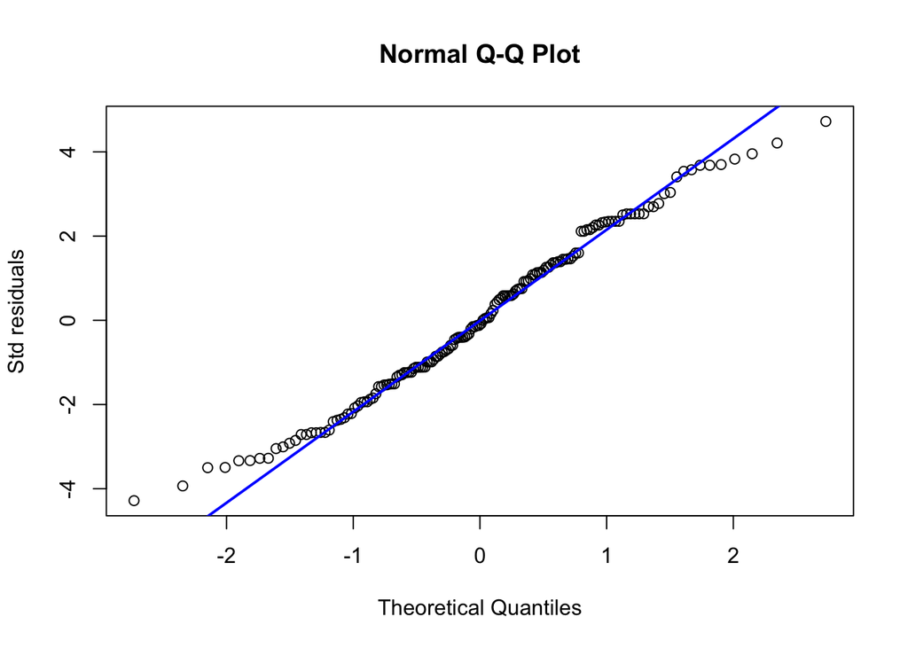

```r
res = resid(model1,type="deviance")
qqnorm(res, ylab="Std residuals")
qqline(res,col="blue",lwd=2)
```

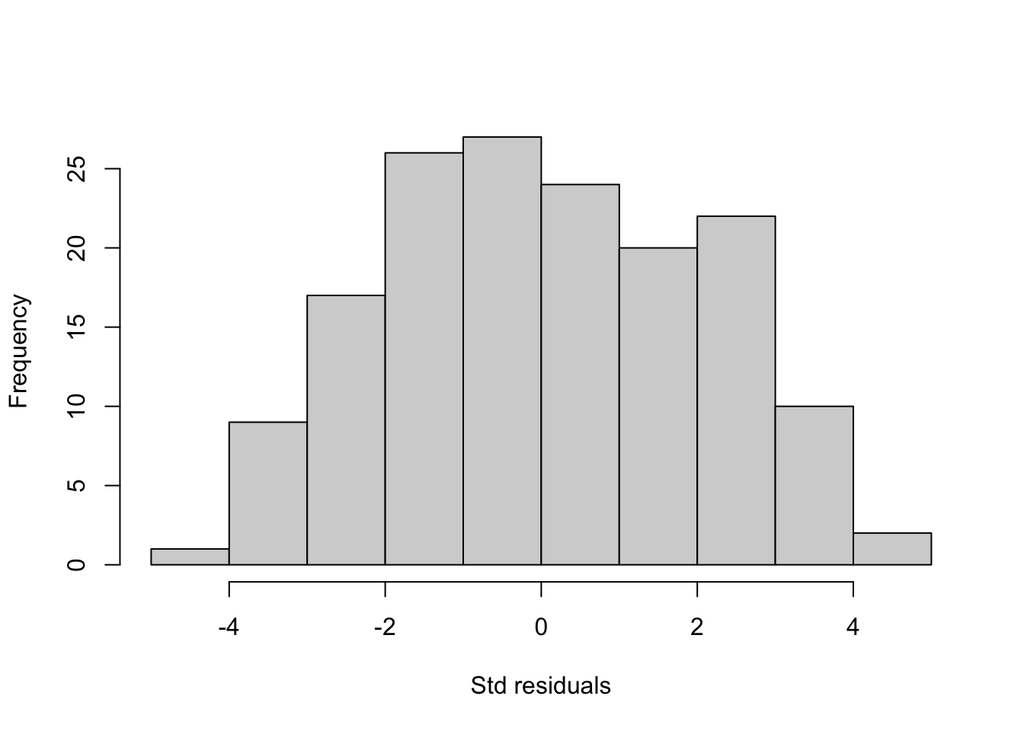

```r
hist(res,10,xlab="Std residuals", main="")
```

3. 3 pts - Calculate the estimated dispersion parameter for this model. Is this an overdispersed model?

# Question 4: Fitting the full model- 23 pts

Fit a logistic regression model using *Staying* as the response variable with *Age.Group*, *Gender*, *Tenure*, *Num.Of.Products*, and *Is.Active.Member* as the predictors and logit as the link function. Ensure to include the weights parameter for specifying the number of trials. Call it **model2**. Note that Age.Group, Gender, Num.Of.Products, and Is.Active.Member should be treated as categorical variables.

(d-1) Perform goodness-of-fit hypothesis tests using both Deviance and Pearson residuals. What do you conclude?

(d-2) Evaluate the linearity assumption of **model2** by plotting the log-odds of Staying vs. **Tenure**. What do you conclude?

(d-3) Evaluate whether the deviance residuals are normally distributed by producing a QQ plot and histogram of the deviance residuals. What do you conclude?

(d-4) Calculate the estimated dispersion parameter for this model. Is this an overdispersed model?

5. 4 pts - Overall, would you say model2 is a good-fitting model? If so, why? If not, what would you suggest to improve the fit and why? Note: We are not asking you to spend hours finding the best possible model but to offer plausible suggestions along with your reasoning.

# Question 5: Prediction - 9 pts

Suppose there is an employee with the following characteristics:

1. **Age.Group**: 2
2. **Gender**: 0
3. **Tenure**: 2
4. **Num.Of.Products**: 2
5. **Is.Active.Member**: 1
1. 3 pts - Predict their probability of staying using model1.

2. 3 pts - Predict their probability of staying using model2.